# Dem Candidate Tweet Trends

AM

March 26, 2016

# Overview

Recently I’ve been interested in how candidates go about shaping their campaign messages & focus via social media. I had a few questions about campaign habits regarding twitter, and haven’t found all the answers from the news sources I follow. I wanted to look at follower engagement, activity & topics within each candidate’s account, and figured this would be a good chance for me to stretch and work with a new type of data. I wouldn’t consider this exhaustively representative, & mostly did it for my own interest, but figured it might be interesting for some.

# Import & cleaning

The major steps of data collection & handling are documented in [another markdown.](https://github.com/hereismyname/2016-candidate-tweet-munging/blob/master/code/dems.Rmd) At this point, we only need to read in the tweets from each candidate and perform some minor cleanup.

```r
library(dplyr)
library(magrittr)
library(readr)

hc <- read_csv("../data/clinton-tweets-2016-03-26.csv", col_types = cols(id = "c"))
bs <- read_csv("../data/sanders-tweets-2016-03-26.csv", col_types = cols(id = "c"))

# combine data & clean
dat <- bind_rows(hc, bs) %>%
  # sort by date
  arrange(screenName, created) %>%
  select(
    # grab relevant variables & rename
    user = screenName,
    id, created, yr, mo,
    favorites = favoriteCount,
    retweets = retweetCount,
    client = statusSource,
    text
  ) %>%
  mutate(
    mo = factor(mo, levels = 1:12, labels = month.name),

    # order the months to show fall '15 in front
    mo = factor(mo, levels = c("July", "August", "September", "October",
                               "November", "December", "January", "February",
                               "March"), ordered = TRUE),

    # rename users by last name
    user = factor(user, levels = c("BernieSanders", "HillaryClinton"),
                  labels = c("Sanders", "Clinton")),

    # strip html tags out
    client = gsub("<.*?>", "", client),

    # add a date variable
    date = as.Date(created),

    # add a time of day variable
    time = strftime(created, "%H:%M:%S") %>% as.POSIXct(., format = "%H:%M:%S")
  )

count(dat, user)
```

```
## Source: local data frame [2 x 2]
##
##      user     n
##    (fctr) (int)
## 1 Sanders  2117
## 2 Clinton  2166
```

Overall, we have an even sample between each candidate, spanning from Fall 2015 to March 2016.

# Analysis

## Subject matter & campaign issues

There are many topics that are of interest to the Democratic nomination campaigns– giving each adequate breadth and depth is beyond what I’m doing here. However, in the absence of exhaustive scrutiny of each candidate’s twitter feed, we’ll take a look at each candidate’s posts more broadly, attempting to get a general sense of what is important to each candidate at a given time. We’ll do this largely through tracking keywords that are reliably associated with specific topics and issues. For example, the list of words/phrases “wage”, “income”, “compensat(ion)”, “an hour”, should generally be associated with tweets discussing the federal minimum wage. This isn’t a foolproof strategy– some keywords will at least partially map onto other topics (e.g. while “compensation” might be seen in tweets discussing the minimum wage, it could also appear in tweets discussing income disparities between men & women); however, this approach should be enough to group candidate tweets into broad categories. I’d like to improve this, but this should be enough to get started. For this analysis, I’m trying to focus on mostly domestic policy. Here are the issues we’ll be searching for:

**1. Race, & Gender**

- Clinton’s candidacy is historic, in that her presence in the race represents a strong chance for the U.S. to elect its first female president. Clinton presents herself as a champion of women’s rights, and argues that her presidency would serve as a bastion against the conservative right. However, in Iowa, New Hampshire, and Nevada, current voting results show the break between Sanders and Clinton largely rests upon the age of voters, rather than gender.
- Minority voters present a similar question of appeal across candidates. Clinton has enjoyed (for better and for worse) incredibly high visibility amongst the American public. Most media outlets expect minority voters to favor Clinton in most contests, and she has performed well in the South. However, as of yesterday, Sanders appears to have done well in several counties in Washington that have high Hispanic/Latino populations, and appears to have won Hawaii by a large margin. I’ve seen at least [one poll this morning](http://polling.reuters.com/#poll/TR131/filters/SC_RACE:2%7C3%7C4%7C5%7C-1,RESP_AGE:-4/dates/20160201-20160322/type/smallest) (from S.C. in February?) that indicates Sanders’s support remains strong among *younger* minority voters.

**2. Income & Wealth Inequality**

- College affordability has been a topic featured consistently in debates and in candidate rallies. Sanders’s campaign has made tax policy a central pillar of its platform, aiming to increase taxes on wealthier Americans & market speculation to fund progams designed to reduce income disparity. Clinton’s campaign has criticized Sanders for being narrowly focused on economic issues; my daring assumption is that Sanders will have a higher number of tweets directly referencing economic issues, and that Clinton will show more diversity in topics, relative to Sanders.

**3. Gun Control**

- Depending on how they’re counted, the US has seen [53 mass shootings thus far in 2016.](http://www.gunviolencearchive.org/query/0484b316-f676-44bc-97ed-ecefeabae077/map) This is an area of weakness Clinton has pressured Sanders on in prior debates, and a solution that will be accepted by the country at-large has not been articulated by the democrats.

**4. Health Care**

- This may be connected more generally with #2, but probably warrants its own category, given that it applies to a specific spending source that is different from other costs of living.

The code searches each candidate’s tweets for the presence of certain keywords related to each topic area. Certain terms are then added together to create a composite score for a topic. If you aren’t interested in checking my work, feel free to scroll-down.

```r
# all keywords ignore casing when applicable-- thus if a term starts a sentence
# it will still be picked up
# composite scores may double-count certain tweets-- i.e. some tweets might
# contain both "race" and "privilege" in the same 140 character string
frames_count <- dat %>%
  group_by(user, mo) %>% # counts generated for each month/candidate
  summarise(
    # total number of tweets each candidate has made per month
    total = n(),

    # instances socialism is mentioned in a tweet
    socialism = sum(grepl("socialism", text, ignore.case = TRUE)),

    # race
    afri     = sum(grepl("afri", text, ignore.case = TRUE)),
    race     = sum(grepl("race", text, ignore.case = TRUE)),
    priv     = sum(grepl("privilege", text, ignore.case = TRUE)),
    white    = sum(grepl("white", text, ignore.case = TRUE)),
    black    = sum(grepl("black", text, ignore.case = TRUE)),
    all_race = sum(afri, race, priv, white, black),

    # gender
    gender  = sum(grepl("Gender", text, ignore.case = TRUE)),
    women   = sum(grepl("Women", text, ignore.case = TRUE)),
    woman   = sum(grepl("Woman", text, ignore.case = TRUE)),
    moms    = sum(grepl("moms", text, ignore.case = TRUE)),
    all_gen = sum(gender, women, woman, moms),

    # college
    college = sum(grepl("college", text, ignore.case = TRUE)),

    # wages
    wage      = sum(grepl("Wage", text, ignore.case = TRUE)),
    an_hour   = sum(grepl("an hour", text)),
    income    = sum(grepl("income", text, ignore.case = TRUE)),
    compensat = sum(grepl("compensat", text, ignore.case = TRUE)),
    all_wage  = sum(wage, an_hour, income, compensat),

    # health care
    health = sum(grepl("health", text, ignore.case = TRUE)),

    # guns
    guns           = sum(grepl("gun", text, ignore.case = TRUE)),
    background_chk = sum(grepl("background check", text, ignore.case = TRUE)),
    guns_all       = sum(guns, background_chk),

    # Flint
    flint    = sum(grepl("Flint", text)),

    # prison
    prisons  = sum(grepl("prison", text, ignore.case = TRUE)),
    criminal = sum(grepl("criminal", text, ignore.case = TRUE)),

    # justice
    justice = sum(grepl("justice", text, ignore.case = TRUE))
  )
```

#### Campaign issue discussion

Three things jump out at me from these plots:

- Clinton & Sanders are most different when it comes to their mentioning of wages and gun control. Sanders consistently emphasizes the former, while Clinton emphasizes the latter.
  - Sanders *really* prefers to avoid talking about guns/gun control.
- Clinton’s renewed emphasis on race can be clearly seen in her account’s tweeting habits during February.
- Compared to Sanders, Clinton’s patterns in regards to most topics seem to be more variable month to month, showing more spikes, whereas Sanders’s counts tend to fluctuate less.

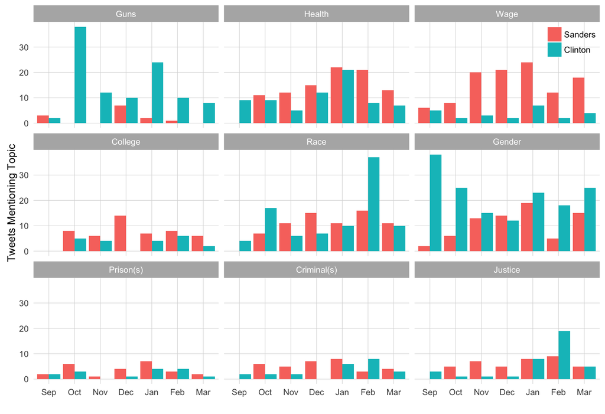

## Daily activity & engagement

On average, Sanders appears to tweet somewhat more frequently than Clinton. However, this is a fairly marginal difference (Cohen’s *d* = 0.35); both tend to hover around 10 tweets on a given day. However, looking at the running average across the primary season shows both candidates generally increasing in the number their accounts are sending.

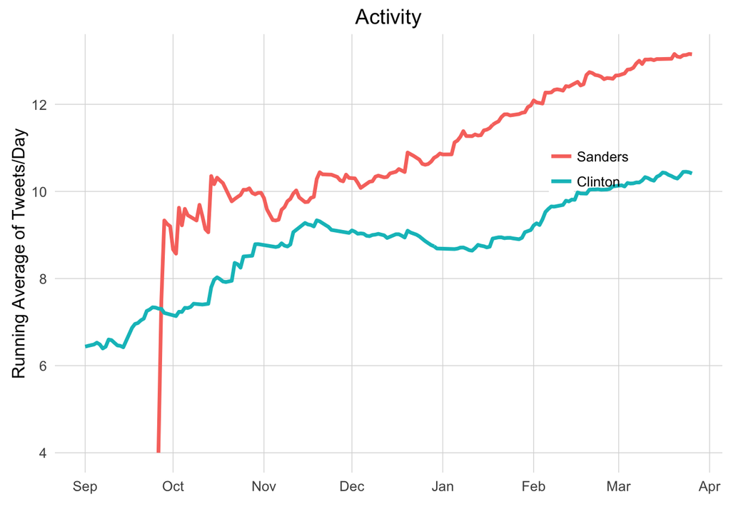

When it comes to engagements & interactions from followers, Sanders appears to have a much more responsive audience. This was something that I was most interested in looking at, given that Clinton’s account has over 3 million more followers than Sanders’s account (I wish I could track how follower counts changed over time, but that wasn’t something I was sure how to do when I wrote this up). I looked at both the median number of interactions & the mean number of interactions, but there weren’t any meaningful differences. Both candidates show fewer retweets compared to favorites on average, but Sanders outperforms Clinton in both categories. I expected at least some residual effect of Clinton’s massive follower count to bring the number of interactions closer between her and Sanders, but apparently it hasn’t been a factor.

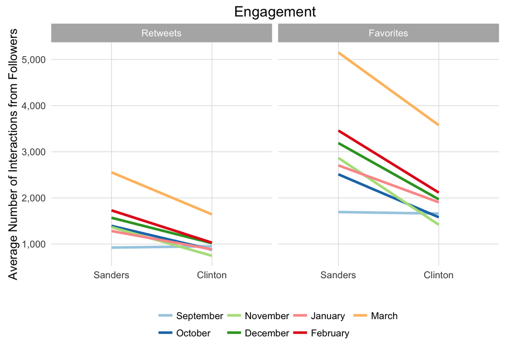

## Miscellaneous

```
## Source: local data frame [13 x 3]
## Groups: user [2]
##
##       user              client     n
##     (fctr)               (chr) (int)
## 1  Sanders           Instagram     1
## 2  Sanders Vine - Make a Scene     1
## 3  Sanders        SnappyTV.com     2
## 4  Sanders         Twitter Ads     3
## 5  Sanders    Twitter for iPad     5
## 6  Sanders Twitter for Android    10
## 7  Sanders  Twitter for iPhone   145
## 8  Sanders  Twitter Web Client   373
## 9  Sanders           TweetDeck  1577
## 10 Clinton         Thunderclap     1
## 11 Clinton  Twitter for iPhone    83
## 12 Clinton  Twitter Web Client   669
## 13 Clinton           TweetDeck  1413
```

```
## Source: local data frame [2 x 2]
##
##      user hashes
##    (fctr)  (int)
## 1 Sanders    659
## 2 Clinton    535
```

```
## Source: local data frame [2 x 2]
##
##      user links
##    (fctr) (int)
## 1 Sanders    57
## 2 Clinton   300
```

- Clinton has made reference to the ongoing water crisis Flint, MI more frequently than Sanders
- Both accounts use TweetDeck most frequently to send tweets; Clinton’s campaign uses the desktop client more often than Sanders’s.
  - Sanders has sent one tweet from Vine.
- Sander’s account tends to use more `#hashtags` (650~ to 530~)
- Both candidates tend to tweet most frequently around 4:30pm EST.

## Some notes on the data & interpretation:

```r
R.version$version.string
```

```
## [1] "R version 3.2.3 (2015-12-10)"
```

```r
packageVersion("dplyr")
```

```
## [1] '0.4.3'
```

```r
packageVersion("reshape2")
```

```
## [1] '1.4.1'
```

```r
packageVersion("ggplot2")
```

```
## [1] '2.1.0'
```

```r
packageVersion("readr")
```

```
## [1] '0.2.2'
```

```r
packageVersion("scales")
```

```
## [1] '0.4.0'
```

```r
packageVersion("magrittr")
```

```
## [1] '1.5'
```